# Mini-Project 6: Eastern Hemlocks on Paradise Pond

Last updated on 2020-10-15

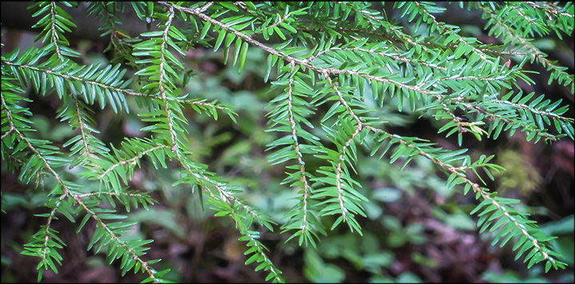

# 1 Eastern Hemlock Data

For this MP we’ll be using data from Marney Pratt’s BIO 131 class.[^1] Here is the data’s [codebook](https://docs.google.com/document/d/1jVz_0ivC6Wpa5bNSG4JoOUp7iQfZJVgOXrfkXwyPeas/edit).

```r
hemlocks <-
  "https://rudeboybert.github.io/SDS390/static/data/hemlocks_pratt.csv" %>%
  read_csv() %>%
  # Drop those in Fitzgerald Lake & MacLeish, keeping only those on Smith campus
  filter(location == "SMC")
```

> It is cold out there - but Smith College Bio 131 students brave the cold to collect data on invasive insects on eastern hemlock trees. [@smithcollege](https://twitter.com/smithcollege?ref_src=twsrc%5Etfw) [pic.twitter.com/YkejCZPEOS](https://t.co/YkejCZPEOS)

> — Marney Pratt (@marney_pratt) [February 27, 2019](https://twitter.com/marney_pratt/status/1100747861778677760?ref_src=twsrc%5Etfw)

# 2 Part 1: Biomass

1. How much Eastern Hemlock biomass is there in the portion of Paradise Pond featured in the Lec13 video? Be mindful of the units.
2. Plot and comment on the relationship between diameter at breast height and above ground biomass.

Hint: use the development version of the [`allodb`](https://github.com/forestgeo/allodb) written by my collaborators at SCBI: Erika Gonzalez-Akre, Mauro Lepore, Camille Piponiot, and Kristina Anderson-Teixeira.

# 3 Part 2: Model relationship between DBH and height

Assume that this set of 31 is a representative sample of ALL Eastern Hemlocks on Smith College campus, and thus any inferences/results based on this sample can *generalize* to all Eastern Hemlocks on Smith College campus.

1. Fit a model, any model, for $y$ = height of the tree using diameter at breast height.
2. A forest ecologist asks “How would you quantify the relationship between tree height and diameter at breast height?” Respond to them.
3. Visualize this model. There are many ways to do this, but here is one way:

```r
library(tidyverse)
library(broom)

# Fit model
mpg_model <- lm(mpg ~ hp, data = mtcars)

# Look at fitted values and residuals using broom::augment()
augment(mpg_model) %>% head()
```

| .rownames | mpg | hp | .fitted | .resid | .std.resid | .hat | .sigma | .cooksd |
| --- | --- | --- | --- | --- | --- | --- | --- | --- |
| Mazda RX4 | 21.0 | 110 | 22.59375 | -1.5937500 | -0.4211862 | 0.0404863 | 3.917367 | 0.0037426 |
| Mazda RX4 Wag | 21.0 | 110 | 22.59375 | -1.5937500 | -0.4211862 | 0.0404863 | 3.917367 | 0.0037426 |
| Datsun 710 | 22.8 | 93 | 23.75363 | -0.9536307 | -0.2534156 | 0.0510291 | 3.924793 | 0.0017266 |
| Hornet 4 Drive | 21.4 | 110 | 22.59375 | -1.1937500 | -0.3154767 | 0.0404863 | 3.922478 | 0.0020997 |
| Hornet Sportabout | 18.7 | 175 | 18.15891 | 0.5410881 | 0.1427178 | 0.0367507 | 3.927666 | 0.0003886 |
| Valiant | 18.1 | 105 | 22.93489 | -4.8348913 | -1.2795289 | 0.0431754 | 3.820288 | 0.0369380 |

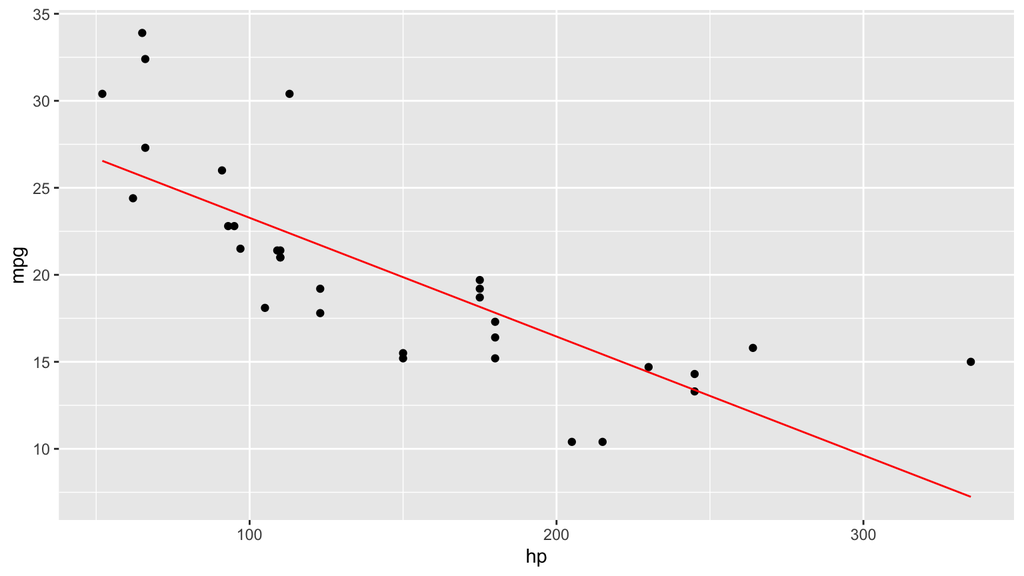

```r
# Visualize observed data with black points and fitted values with red line
ggplot() +
  geom_point(data = mtcars, aes(x = hp, y = mpg)) +
  geom_line(data = augment(mpg_model), aes(x = hp, y = .fitted), col = "red")
```

[^1]: Many thanks Marney!